# Pseudo Absence Bayes Regs

# Bring in Rasters:

Here are our posterior coefficients (from post.pa.full): (Intercept) -3.3 0.4  
b2pa.dist.ps -1.4 0.1  
b2met.dist.ps -1.3 0.2  
dom.farms.psCattle ranching and farming [1121] -0.3 0.4  
dom.farms.psFruit and tree nut farming [1113] 1.1 0.5  
dom.farms.psOther animal production [1129] 1.5 0.4  
dom.farms.psOther crop farming [1119] 1.6 0.5  
dom.farms.psVegetable and melon farming [1112] 0.3 0.7  
total.farms.ps -0.3 0.3  
total.farms.sq.ps 0.5 0.1  
pop.dens 0.7 0.1

```r
# Make sure extents match:
ext(dist2PA.rast) == ext(dist2met.rast) # TRUE
```

```
## [1] TRUE
```

```r
ext(dist2met.rast) == ext(tot.farms.rast) #TRUE
```

```
## [1] TRUE
```

```r
ext(tot.farms.rast) == ext(hm.dens.rast) #TRUE
```

```
## [1] TRUE
```

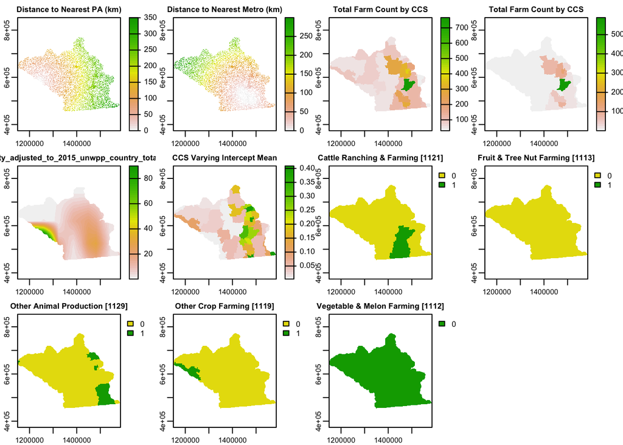

```r
# Stack these spatrasters:
conf.stack <- c(dist2PA.rast, dist2met.rast, tot.farms.rast, tot.farms.sq.rast, hm.dens.rast, ccs.varint.rast, cattle.ranching.rast, fruit.tree.nut.rast, other.animal.rast, other.crop.rast, veg.melon.rast)
plot(conf.stack) # plot these all to check
```

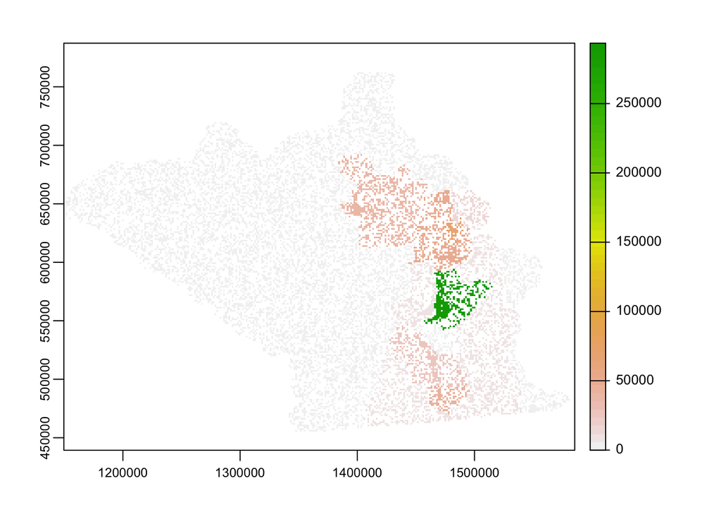

```r
# Create P(all conflict) raster with our regression coefficients:
    # Prob_conf_rast = Int.val + CCS + B_1est * PopDens…
p_conf_rast <- -3.3 + ccs.varint.rast + (-1.4 * dist2PA.rast) + (-1.3 * dist2met.rast) + (-0.3 * tot.farms.rast) +  (0.5 * tot.farms.sq.rast) + (0.7 * hm.dens.rast) + (-0.3 * cattle.ranching.rast) + (1.1 * fruit.tree.nut.rast) + (1.5 * other.animal.rast) + (1.6 * other.crop.rast) + (0.3 * veg.melon.rast)

plot(p_conf_rast)
```